# Final Project

Scott Lanoue

5/18/2018

## Introduction

As as Astronomy minor, I though it would be cool to look at Nasa’s dataset on Near Earth Objects, NEOs, and see what data science we can perform on the dataset. In this tutorial, I will walk through the process of data gathering / curation, data tidying / cleanup, exploratory data analysis, and hypothesis testing.

– Gathering data  
– Tidying data  
– Exploratory data analysis  
– Hypothesis Testing  
– Further Research

Before continuing, it might help to understand some more about NEOs:

Definition: Near-Earth Objects (NEOs) are comets and asteroids that have been nudged by the gravitational attraction of nearby planets into orbits that allow them to enter the Earth’s neighborhood (https://cneos.jpl.nasa.gov/about/basics.html). For more information about NEOs please visit: https://cneos.jpl.nasa.gov/about/basics.html

Additionally, an Astronomical Unit (AU) is a standard unit of measurement defined as 1 times the distance from the Sun’s core to Earth’s core around its axis on average, which is roughly 1.5 x 10^8 km == 1.5 x 10*11 m

This dataset serves as a great example for a tutorial on the data science pipeline due to the size and structure of this data. The data in the table reflects real Near Earth Objects that have actually been detected as well as predictions up to the year 2200.

# Getting the dataset

On NASA’s JPL page: https://cneos.jpl.nasa.gov/ca/, they provide a table of entries. However, by default it is only the last 60 days worth of close encounters. Instead, change this to ‘All Available Data,’ wait for a seconds for it to process, and then we can export the data directly to CSV. A CSV is a comma-separated values file format, which is a standard way to store a data table. Then we call na.omit() immediately in order to remove any missing data– since the dataset is quite large, neglecting the small pieces of data that are missing information will not harm the rest of the data.

```r
# First load the data from the CSV file
ca_data <- read_csv("/Users/scott/Documents/cneos_closeapproach_data.csv") %>%
  na.omit()

ca_data
```

```
## # A tibble: 17,320 x 9
##    Object     `Close-Approach (C… `CA Distance Nomina… `CA Distance Minim…
##    <chr>      <chr>               <chr>                <chr>
##  1 509352 (2… 1900-Jan-04 22:25 … 3.75 | 0.00963       3.75 | 0.00962
##  2 (2014 SC3… 1900-Jan-11 01:03 … 15.55 | 0.03995      15.52 | 0.03989
##  3 4660 Nere… 1900-Jan-29 18:22 … 8.09 | 0.02079       8.08 | 0.02077
##  4 (2015 RW8… 1900-Feb-04 02:31 … 12.63 | 0.03245      12.46 | 0.03201
##  5 (2009 BW2) 1900-Feb-04 11:05 … 6.86 | 0.01763       6.40 | 0.01644
##  6 (2002 LY1) 1900-Feb-05 22:08 … 19.09 | 0.04904      19.08 | 0.04903
##  7 348306 (2… 1900-Feb-05 23:42 … 13.27 | 0.03409      13.27 | 0.03409
##  8 378160 (2… 1900-Feb-10 05:07 … 14.35 | 0.03689      14.30 | 0.03675
##  9 (2012 SD2… 1900-Feb-18 08:31 … 15.69 | 0.04032      15.69 | 0.04031
## 10 (2013 RZ5) 1900-Feb-27 20:23 … 13.57 | 0.03486      8.74 | 0.02246
## # ... with 17,310 more rows, and 5 more variables: `V relative
## #   (km/s)` <dbl>, `V infinity (km/s)` <dbl>, `H (mag)` <chr>, `Estimated
## #   Diameter` <chr>, X9 <chr>
```

# Tidying the dataset

Now, the dataset provided includes a plethora of information, some of which we do not need to use. For example, the data provides ‘CA Distance Nominal (LD | au)’ which is the close approach distance, in both lunar distance and astronomical units. We can negelct the lunar distance and instead look directly at the AU, which is more often used as a standard unit of measure. Now, we can convert CA Distance Nominal (LD | au) to CA Distance (AU), reflecting how close the object will come near Earth. Additionally, we will neglect the error rates in the CA Date and convert it into a datetime. We will turn the velocities into proper numerics as well. Lastly, we will turn the range Estimated Diameter into a est_min_diameter and est_max_diameter that reflects the size in meters of the object.

```r
ca_data <- ca_data %>%
  separate(col = 'CA Distance Nominal (LD | au)', into = c('ca_distance_ld', 'ca_distance_au'), sep = '\\s\\|\\s') %>%
  separate(col = 'CA Distance Minimum (LD | au)', into = c('ca_minimum_ld', 'ca_minimum_au'), sep = '\\s\\|\\s') %>%
  separate(col = 'Close-Approach (CA) Date', into = c('ca_date', 'ca_date_error_rate'), sep = '\\s±\\s') %>%
  separate(col = 'Estimated Diameter', into = c('est_min_diameter', 'est_max_diameter'), sep = '\\s-\\s+') %>%
  na.omit() %>%

  ## Create the est_min_diameter by separating units from magnatitude and do some math
  separate(col = 'est_min_diameter', into = c('est_min_diameter_mag', 'est_min_diameter_unit'), sep = '[[:space:]]', convert = TRUE, remove=FALSE) %>%
  mutate(est_min_diameter = as.double(ifelse(est_min_diameter_unit == "km", est_min_diameter_mag * 1000, est_min_diameter_mag))) %>%

  ## Create the est_max_diameter by separating units from magnatitude and do some math
  separate(col = 'est_max_diameter', into = c('est_max_diameter_mag', 'est_max_diameter_unit'), sep = '[[:space:]]', convert = TRUE, remove=FALSE) %>%
    mutate(est_max_diameter = as.double(ifelse(est_max_diameter_unit == "km", est_max_diameter_mag * 1000, est_max_diameter_mag))) %>%

  ## Converts the Velocities into proper doubles
  transform(as.double('V relative (km/s)')) %>%

  type_convert(cols(ca_date=col_datetime(format='%Y-%b-%d %H:%M')))

## Remove extra rows that we created in the cleaning process
ca_data$ca_distance_ld <- NULL
ca_data$ca_minimum_ld <- NULL
ca_data$ca_date_error_rate <- NULL
ca_data$est_min_diameter_unit <- NULL
ca_data$est_min_diameter_mag <- NULL
ca_data$est_max_diameter_unit <- NULL
ca_data$est_max_diameter_mag <- NULL
ca_data$'H (mag)' <- NULL

## Rename the velocity columns
names(ca_data)[names(ca_data) == 'V relative (km/s)'] <- 'velocity_relative'
names(ca_data)[names(ca_data) == 'V infinity (km/s)'] <- 'velocity_infinity'

## Print out the dataset so that we can take a nice long look at our work
ca_data
```

```
## # A tibble: 17,311 x 9
##    Object                ca_date             ca_distance_au ca_minimum_au
##    <chr>                 <dttm>                       <dbl>         <dbl>
##  1 509352 (2007 AG)      1900-01-04 22:25:00        0.00963       0.00962
##  2 (2014 SC324)          1900-01-11 01:03:00        0.0400        0.0399
##  3 4660 Nereus (1982 DB) 1900-01-29 18:22:00        0.0208        0.0208
##  4 (2015 RW83)           1900-02-04 02:31:00        0.0324        0.0320
##  5 (2009 BW2)            1900-02-04 11:05:00        0.0176        0.0164
##  6 (2002 LY1)            1900-02-05 22:08:00        0.0490        0.0490
##  7 348306 (2005 AY28)    1900-02-05 23:42:00        0.0341        0.0341
##  8 378160 (2006 WX1)     1900-02-10 05:07:00        0.0369        0.0368
##  9 (2012 SD22)           1900-02-18 08:31:00        0.0403        0.0403
## 10 (2013 RZ5)            1900-02-27 20:23:00        0.0349        0.0225
## # ... with 17,301 more rows, and 5 more variables:
## #   velocity_relative <dbl>, velocity_infinity <dbl>,
## #   est_min_diameter <dbl>, est_max_diameter <dbl>, X9 <chr>
```

Now that we have a nice clean and tidy dataset, we can start to do some Exploratory Data Analysis in order to learn more about the dataset.

# Exploratory Data Analysis

First, lets look at a distribution of NEO over time

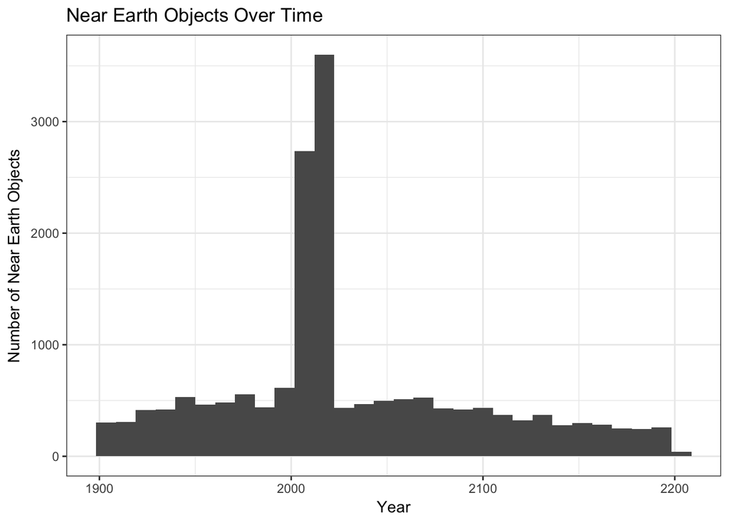

```r
# We only want to group by year, not by full date
ca_data %>%
  mutate(year = year(ca_date)) %>%
  group_by(year) %>%
  ggplot(mapping=aes(x=year)) +
    geom_histogram() +
    labs(title="Near Earth Objects Over Time",
         x="Year",
         y="Number of Near Earth Objects")
```

From this graph, we see that the most amount of NEO is around the year 2010 or so, which has to be more than coincidental, right? Yes, the clear explanation as for why there are so many more NEO arround the current year is due to the fact that prior to 2000, we probably did not have the technology to find as many NEO nor were we looking for such objects. Additionally, in the future, we can only detect large objects with detectable paths, and we cannot detect NEO that we have not seen before. Therefore, it makes sense that the data shows the most amount of NEO around the current year. Maybe if we wanted to attempt to predict some of the future, we can look at data up until today, and then compare our results against the actual forecasted NEO data, but more on that later, lets do a bit more analysis for now.

While it is great that we can see the distribution of NEO over time, I think it might be cool to see the largest and closest NEO that have already happened.

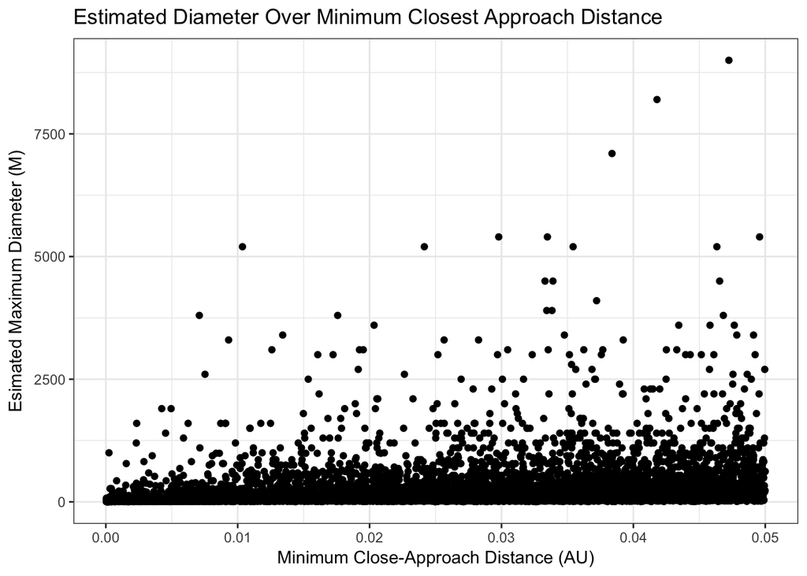

```r
# First we want to filter our data to events that have actually happened / might happen this year
ca_data %>%
  mutate(year = year(ca_date)) %>%
  filter(year < 2018) %>%
  ggplot(mapping=aes(x=ca_minimum_au, y=est_max_diameter)) +
    geom_point() +
    labs(title="Estimated Diameter Over Minimum Closest Approach Distance",
         x="Minimum Close-Approach Distance (AU)",
         y="Esimated Maximum Diameter (M)")
```

Now, I want to look at a similar graph to the last, but look at object velocity as well.

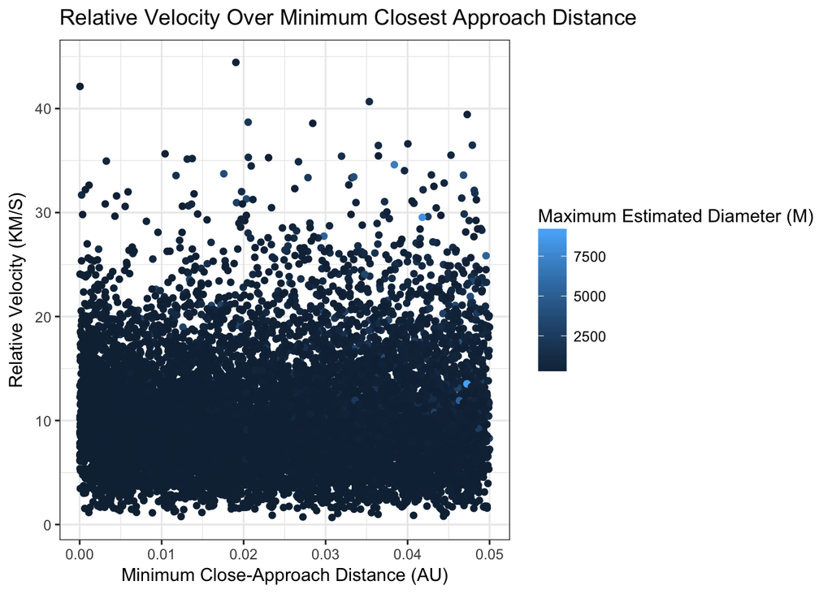

```r
# Similar structure as before
ca_data %>%
  mutate(year = year(ca_date)) %>%
  filter(year < 2018) %>%
  ggplot(mapping=aes(x=ca_minimum_au, y=velocity_relative)) +
    geom_point(mapping=aes(color=est_max_diameter)) +
    labs(title="Relative Velocity Over Minimum Closest Approach Distance ",
         x="Minimum Close-Approach Distance (AU)",
         y="Relative Velocity (KM/S)",
         color="Maximum Estimated Diameter (M)")
```

This graph now allows as us to look at Close Approach Distance, Relative Velocity, *and* Diameter of each NEO from 1900 - 2018 more easily. We can see that the largest NEO from the last graph is now shaded a bright blue but it is buried under the crowd around it, meaning that it has a rather standard relative velocity. Since most NEO are reminants leftover from the creation of the solar system, it makes sense that they all have very similar velocities, regardless of distance or size. Let’s look at the distrubtion of relative velocity over size in order to see that this is true.

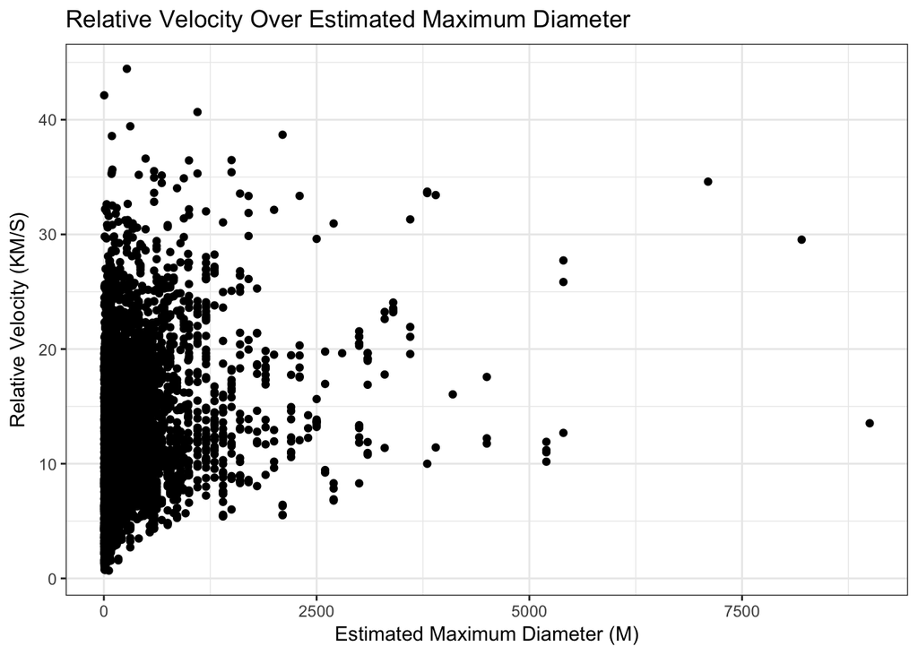

```r
ca_data %>%
  mutate(year = year(ca_date)) %>%
  filter(year < 2018) %>%
  ggplot(mapping=aes(x=est_max_diameter, y=velocity_relative)) +
    geom_point() +
    labs(title="Relative Velocity Over Estimated Maximum Diameter ",
         x="Estimated Maximum Diameter (M)",
         y="Relative Velocity (KM/S)")
```

As we can see, there does not look to be any sort of connection between the relative velocity and the estimated maximum diameter of the NEO. Again, this makes sense, since the source of NEOs are probably from leftover remnants from stellar formation.

Although there may not be a relation between relative velocity and the diameter of the NEO, recall that there may be a relationship between the diameter of a NEO and how close it approaches to Earth.

# Hypothesis Testing

Recall from the last section that we have a theory: larger objects seem to not come as close to Earth as smaller objects. Let’s reword this a little just to make sure our hypothesis is clear: Near Earth Objects that have a higher estimated maximum diameter will not come as close to Earth as objects with smaller estimated maximum diameters.

Now, lets begin to formulate a test that we can carry out to prove that there is a relationship here and that our hypothesis is correct.

```r
ca_data_fit <- lm(ca_minimum_au~est_max_diameter, data=ca_data)

ca_data_fit_tidy <- ca_data_fit %>%
  tidy()

ca_data_fit_tidy
```

```
##               term     estimate    std.error statistic       p.value
## 1      (Intercept) 2.397066e-02 1.170485e-04 204.79257  0.000000e+00
## 2 est_max_diameter 6.345028e-06 2.115495e-07  29.99311 9.990327e-193
```

While this initially may seem confusing, it makes a simple point: As the estimated max diameter of a NEO increases by one meter, the closest approach minimum distance increases by 6.345028e-06 AU, which is ~949214 m. Additionally, this shows us a p-value of 9.9e-193, which is incredibly small, much smaller than 0.05 (a standard p-test score), which means we reject the null hypothesis of *no* relationship, meaning that there is a relationship between the maximum diameter and how close an object will get to Earth. Interesting!!!

We can actually add a line of best fit to our graph in order to see if there actually is a relationship and whether the fitted line actually reflects the data.

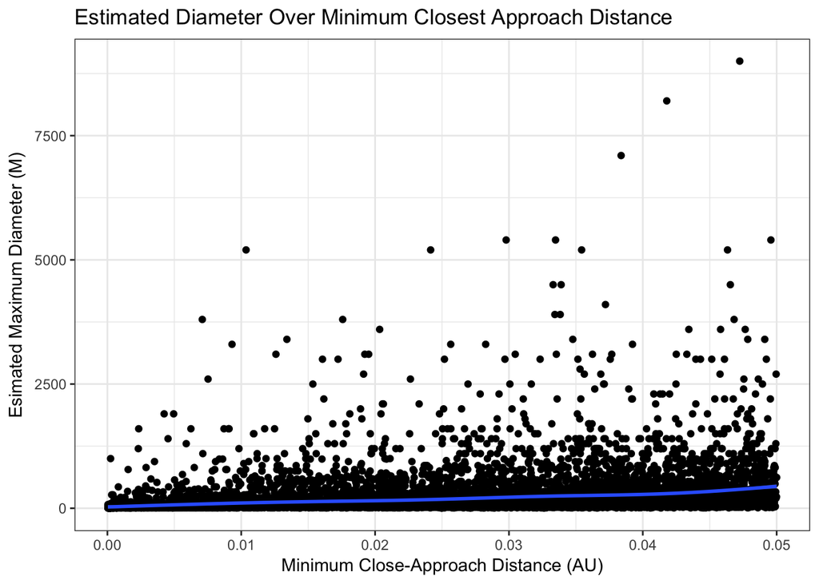

```r
ca_data %>%
  mutate(year = year(ca_date)) %>%
  filter(year < 2018) %>%
  ggplot(mapping=aes(x=ca_minimum_au, y=est_max_diameter)) +
    geom_point() +
    stat_smooth(span = 0.2) +
    labs(title="Estimated Diameter Over Minimum Closest Approach Distance",
         x="Minimum Close-Approach Distance (AU)",
         y="Esimated Maximum Diameter (M)")
```

Now, we can look at the residuals and the model in order to determine how well the data fit, visually.

First, let us look at the plot of residuals versus close approach distance.

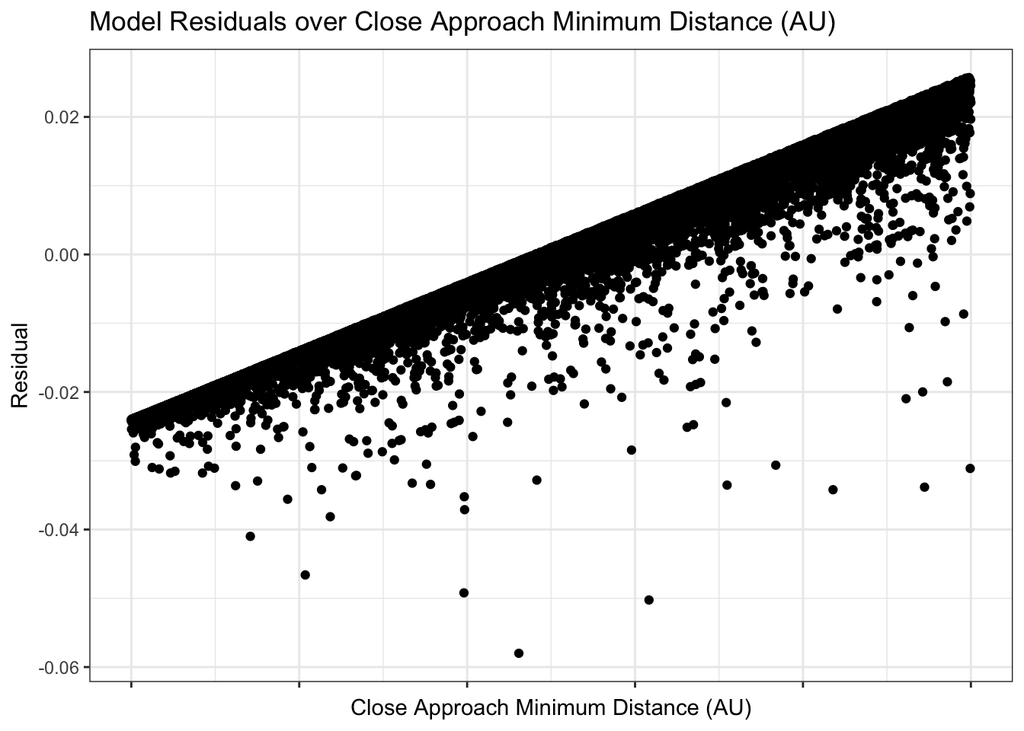

```r
augment_ca_data_fit <- ca_data_fit %>%
  augment()

augment_ca_data_fit %>%
  ggplot(aes(x=ca_minimum_au, y=.resid)) +
  labs(title="Model Residuals over Close Approach Minimum Distance (AU)",
       x = "Close Approach Minimum Distance (AU)",
       y = "Residual") +
  theme(axis.text.x = element_blank()) +
  geom_point()
```

This model tells us that our data is a decent fit, since the data seems to be close to 0. However, we can see that there is clrealy a trend, as the CA Distance goes up, the residual goes up as well. This means that a linear regression might not be the absolute best fit for our data, and that a more robust regression analysis such as using regression trees.

Then, we will look at each residual versus it’s fitted model.

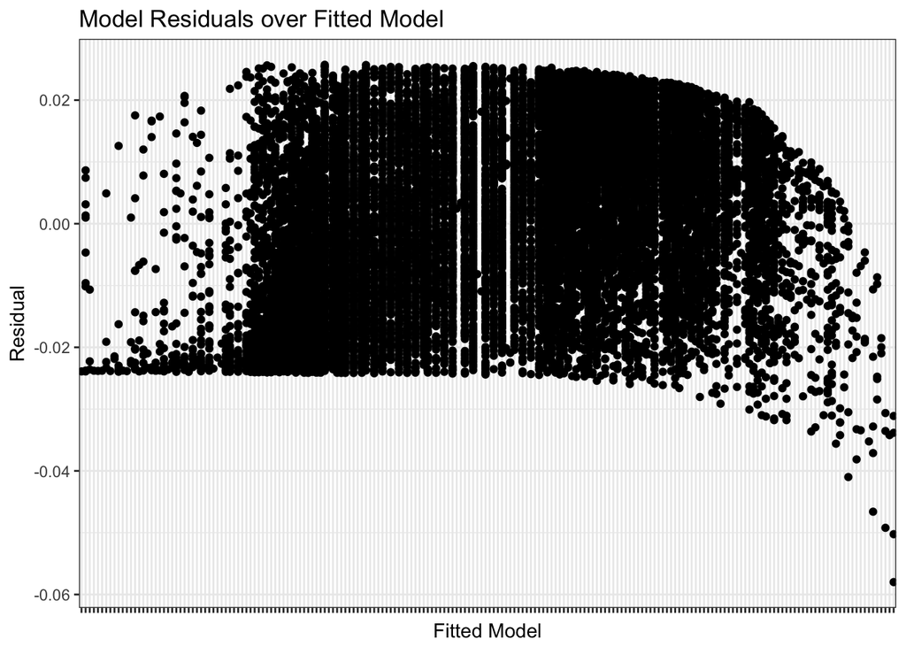

```r
augment_ca_data_fit <- ca_data_fit %>%
  augment()

augment_ca_data_fit %>%
  ggplot(aes(x=factor(.fitted), y=.resid)) +
  labs(title="Model Residuals over Fitted Model",
       x = "Fitted Model",
       y = "Residual") +
  theme(axis.text.x = element_blank()) +
  geom_point()
```

## Further Research

This tutorial should serve as an excellent introduction into the world of data science using R. Using a NASA Dataset, this tutorial has taught the reader how to import data using a csv file, how to tidy and clean a dataset for operations, and how to conduct exploratory data analysis on a dataset. For more information, please visit these very helpful links that have helped me in my journey through data science:

- https://www.rstudio.com/wp-content/uploads/2015/03/ggplot2-cheatsheet.pdf
- http://www.hcbravo.org/IntroDataSci/bookdown-notes/index.html
- https://cran.r-project.org/web/packages/dplyr/vignettes/dplyr.html
- https://cran.r-project.org/doc/manuals/r-release/R-intro.pdf

Further analysis of this dataset might utilize machine learning in order to compare predictions utilizing the dataset and the predictions provided by NASA in the dataset.